# Graduate Project

Mary McBride

2020-04-24

### Load packages

```r
install.packages("rpart.plot")
library(tidyverse)
library(tidymodels)
library(rpart.plot)
```

For my analysis, I found a data set on Kaggle that included reviews and ratings of food items bought on Amazon. I decided to look at whether I could predict the rating given, based on the length of the review.

Prediction question: Am I able to predict the rating given to a food product based on the corresponding length of the review?

The data set that I found had 11 variables, but I only focused on Score (overall rating from 1 to 5) and Text ( written review that buyer left). The first thing that I did was read in the data from Excel. I then added a column to the data set that counted the number of characters left in the review. I called this noChar.

```r
set.seed(7)
review <- read_csv("Reviews.csv")
review$noChar <- nchar(review$Text)
```

Next, I split the data into testing and training sets. I also set up cross validation to be used in tuning later.

```r
set.seed(7)
review_split <- initial_split(review, prop = 0.5)

set.seed(7)
review_train <- training(review_split)

set.seed(8)
review_cv <- vfold_cv(review , v = 10)
```

I first decided to fit a regular decision tree. I thought this would be helpful to visualize the data since I am able to plot the tree. I tuned the cost complexity and found that .002 gave me the smallest RMSE.

```r
tree_spec <- decision_tree(
  cost_complexity = tune(),
  tree_depth = 10,
  mode = "regression") %>%
  set_engine("rpart")

grid <- expand_grid(cost_complexity = seq( 0, .05, by =.001))

set.seed(7)
results <- tune_grid(tree_spec,
                     Score ~ noChar,
                     grid = grid,
                     resamples = review_cv)
```

[output not shown]

[output not shown]

[output not shown]

[output not shown]

[output not shown]

[output not shown]

[output not shown]

[output not shown]

[output not shown]

[output not shown]

```r
set.seed(7)
results %>%
  collect_metrics() %>%
  filter(.metric == "rmse") %>%
  arrange(mean)
```

```
## # A tibble: 51 x 6
##    cost_complexity .metric .estimator  mean     n std_err
##              <dbl> <chr>   <chr>      <dbl> <int>   <dbl>
##  1           0.002 rmse    standard    1.31    10  0.0131
##  2           0.003 rmse    standard    1.31    10  0.0131
##  3           0.001 rmse    standard    1.31    10  0.0137
##  4           0.004 rmse    standard    1.31    10  0.0133
##  5           0.005 rmse    standard    1.31    10  0.0136
##  6           0.006 rmse    standard    1.31    10  0.0136
##  7           0.007 rmse    standard    1.31    10  0.0136
##  8           0.008 rmse    standard    1.31    10  0.0136
##  9           0.009 rmse    standard    1.31    10  0.0136
## 10           0.01  rmse    standard    1.31    10  0.0136
## # … with 41 more rows
```

```r
final_complexity <- results %>%
  select_best(metric = "rmse") %>%
  pull()
```

Next I wanted to plot the decision tree. Based on the output, this model seems to be better at predicting higher scores than lower scores. It does not tell us any information about scores lower than 2.6.

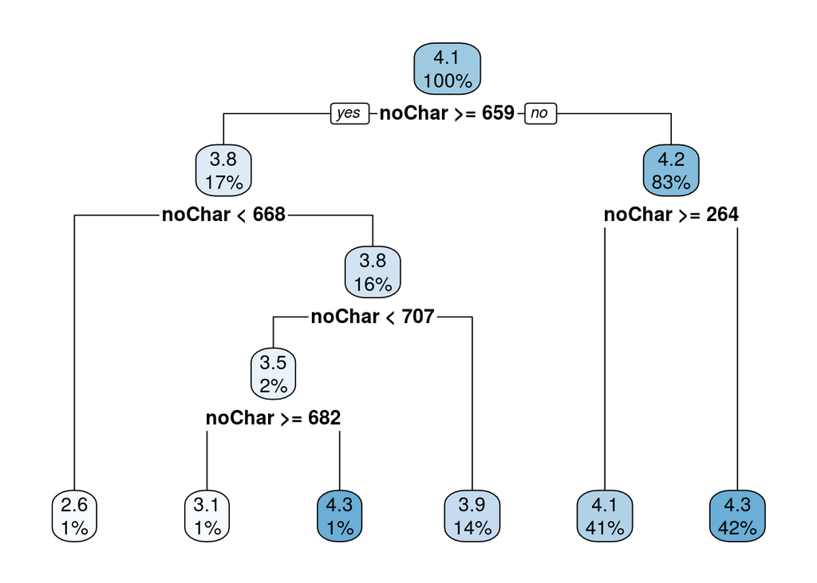

```r
tree_plot <- decision_tree(
  cost_complexity = final_complexity,
  tree_depth = 10,
  mode = "regression") %>%
  set_engine("rpart")
model <- fit(tree_plot,
                   Score ~ noChar,
             data= review_train)

rpart.plot(model$fit,
           roundint = FALSE )
```

Finally, I found the RMSE for the testing data to make sure that my model did not overfit the training data. The RMSE was 1.305, which I think is not very accurate when you consider that the overall ratings have to be between a 1 and 5.

```r
review_test <- testing(review_split)

final_model <- fit(tree_plot,
                   Score ~ noChar,
                   data = review_train)





final_model %>%
  predict(new_data = review_test) %>%
  bind_cols(review_test) %>%
  metrics(truth = Score, estimate = .pred)
```

```
## # A tibble: 3 x 3
##   .metric .estimator .estimate
##   <chr>   <chr>          <dbl>
## 1 rmse    standard      1.30
## 2 rsq     standard      0.0116
## 3 mae     standard      1.04
```

```r
boost_spec <- boost_tree(
  mode = "regression",
  tree_depth = 1,
  trees = tune(),
  learn_rate = 0.1,
) %>%
  set_engine("xgboost")

grid <- expand_grid(trees = seq( 0, 500, by =25))



set.seed(7)
results <- tune_grid(boost_spec,
                     Score ~ noChar,
                     grid = grid,
                     resamples = review_cv)


results %>%
  collect_metrics() %>%
  filter(.metric == "rmse") %>%
  arrange(mean)
```

```
## # A tibble: 21 x 6
##    trees .metric .estimator  mean     n std_err
##    <dbl> <chr>   <chr>      <dbl> <int>   <dbl>
##  1    50 rmse    standard    1.31    10  0.0129
##  2    75 rmse    standard    1.31    10  0.0133
##  3   100 rmse    standard    1.31    10  0.0133
##  4   125 rmse    standard    1.31    10  0.0134
##  5   150 rmse    standard    1.31    10  0.0134
##  6   175 rmse    standard    1.31    10  0.0134
##  7   200 rmse    standard    1.31    10  0.0134
##  8   225 rmse    standard    1.31    10  0.0134
##  9   250 rmse    standard    1.31    10  0.0135
## 10   275 rmse    standard    1.31    10  0.0135
## # … with 11 more rows
```

```r
final_complexity2 <- results %>%
  select_best(metric = "rmse") %>%
  pull()
```

```r
boost_fin <- boost_tree(
  mode = "regression",
  tree_depth = 1,
  trees = final_complexity2,
  learn_rate = 0.1,
) %>%
  set_engine("xgboost")






final_model <- fit(boost_fin,
                   Score ~ noChar,
                   data = review_train)





final_model %>%
  predict(new_data = review_test) %>%
  bind_cols(review_test) %>%
  metrics(truth = Score, estimate = .pred)
```

```
## # A tibble: 3 x 3
##   .metric .estimator .estimate
##   <chr>   <chr>          <dbl>
## 1 rmse    standard      1.29
## 2 rsq     standard      0.0189
## 3 mae     standard      1.04
```

Overall, while I think that it would be very interesting to be able to predict the rating just by looking at the length of review, however, I don’t know that any model will be able to do so accurately. I think that the length of the review has more to do with personality type or another variable verses whether you enjoyed the product. I think this would be an interesting topic of further study.

Link to data from Kaggle : https://www.kaggle.com/snap/amazon-fine-food-reviews I had to cut down some of the data because it was too large for my computer/ internet to handle.